# Cognición Bayesiana

Santiago Alonso-Díaz, PhD

Universidad Javeriana

# Posteriors, priors, & likelihoods

Prior (creencias)

Likelihood (data)

[figure not shown]

Prior (creencias)

Likelihood (data)

[figure not shown]

### ¿Extraterrestes? ¿Likelihood? ¿Prior?

[figure not shown]

Bayes formalizó como combinar priors y likelihoods

$$ Posterior = \frac{Prior \times Likelihood}{Marginal} $$

Veamos la misma formula con otros "nombres"

$$ Belief_{t+1} = \frac{Belief_t \times Likelihood}{Marginal} $$

Veamos la misma formula expandida

$$ p(Hypothesis|Data) = \frac{p(Hypothesis) \times p(Data|Hypothesis)}{p(Data)} $$

# Prueba del teorema

[figure not shown]

# Visualización de posteriors, priors, y likelihoods

## Espacio de hipótesis (eventos)

[figure not shown]

## Espacio de hipótesis (eventos)

[figure not shown]

## Priors

[figure not shown]

## Datos

### El marginal es la probabilidad de la data (gris dividido toda el área del espacio de hipótesis)

[figure not shown]

## Likelihoods

[figure not shown]

## Posterior

[figure not shown]

## Posterior vs. likelihood

[figure not shown]

# Cognición bayesiana:

### Combinar datos y creencias con el teorema

¿Qué prefiere **azulito**?

[figure not shown]

¿Qué prefiere **azulito**?

[figure not shown]

**Azulito** pide ayuda ¿Pereza?

[figure not shown]

¿Quién es más malo? ¿ **verde**? ¿ **rojo**?

[figure not shown]

Inferencia sobre estados latentes de **azulito** (e.g. preferencias) con el teorema de Bayes

$$ p(Preferencia|Accion) \propto p(Accion|Preferencia)p(Preferencia)$$

Por ejemplo, likelihood normal y prior uniforme

[figure not shown]

# Dos formas para obtener la posterior

### Análisis matemático

### Simulaciones (e.g. MCMC)

# Forma 1: Análisis matemático.

### Caso: Likelihood & prior Normal

Descripción de un problema estadístico simple:

1. Una sola observación X para justificar una hipótesis llamada `H`.
2. ¿Qué tanto creemos en `H` dada la observación X?

Solución en lenguaje natural:

Creencia en H es proporcional a la probabilidad de que X ocurra si H es verdad. Todo ponderado por mi creencia previa en H

En lenguaje de Bayes: \begin{equation} Posterior \propto Likelihood \times Prior \\ p(H|X) \propto p(X|H) \times p(H) \end{equation}

En lenguaje de distribuciones de probabilidad: \begin{equation} p(H|X) \propto Normal(X|\mu=H, \sigma^2) \times Normal(H|\mu=H_0, \sigma^2_0) \end{equation}

Nota: conocemos $H_0$, $\sigma^2_0$, y $\sigma^2$.

Ahora podemos empezar la solución analítica

Recordemos la formula de la densidad normal de una variable x con promedio $\mu$ y desv. estandar $\sigma$ \begin{equation} \frac{1}{\sqrt{2\pi \sigma^2}} e^{\frac{-(x-\mu)^2}{2\sigma^2}} \end{equation}

Tenemos que multiplicar dos normales:  
\begin{equation} p(H|X) \propto Normal(X|\mu=H, \sigma^2) \times Normal(H|\mu=H_0, \sigma^2_0) \end{equation}

Reemplazemos las normales por sus formulas: \begin{equation} p(H|X) \propto \frac{1}{\sqrt{2\pi \sigma^2}} e^{\frac{-(x-H)^2}{2\sigma^2}} \times \frac{1}{\sqrt{2\pi \sigma^2_0}} e^{\frac{-(H-H_0)^2}{2\sigma^2_0}} \end{equation}

Luego de algo de algebra ... \begin{equation} p(H|X) = \frac{1}{\sqrt{2\pi \sigma^2_1}} e^{\frac{-(\mu-\mu_1)^2}{2\sigma^2_1}} \end{equation}

Donde \begin{equation} \sigma^2_1 \;\; = \;\; \left( \frac{1}{\sigma^2} \;\;+\;\; \frac{1}{\sigma^2_0}\right)^{-1} \\ \mu_1 = \frac{\mu_0\sigma^{-2}_0 + X\sigma^{-2}}{\sigma^{-2}+\sigma^{-2}_0} \end{equation}

Nota: cuando X son n observaciones independientes, $\sigma^2$ se divide por n y X es $\overline{X}$

En lenguaje natural:

Nuestra creencia en H tiene una probabilidad gaussiana.

\begin{equation} p(H|X) \sim Normal(\mu_1, \sigma^2_1) \end{equation}

Su promedio $\mu_1 $ depende de $\mu_0$ (promedio del prior) y $\overline{X}$ (promedio de la data), ponderados y escalados por la precisión de sus distribuciones ($\sigma^{-2}_0$ y $\sigma^{-2}$).

\begin{equation} \frac{\mu_0\sigma^{-2}_0 + \overline{X}\frac{\sigma^{-2}}{n}}{\frac{\sigma^{-2}}{n}+\sigma^{-2}_0} \end{equation}

Su varianza $\sigma^2_1 $ depende de las desviaciones estandar del likelihood y el prior

\begin{equation} \left( \frac{1}{\frac{\sigma^2}{n}} \;\;+\;\; \frac{1}{\sigma^2_0}\right)^{-1} \end{equation}

# Forma 2: Simulaciones (MCMC)

Rejection sampling:  
Tomar muestras de p(x) (gris) indirectamente con una distribución más simple $M q (x)$ más alta que p(x) (blanca). N son iteraciones (no muestras).

[figure not shown]

Fuente: Andrieu, et al, (2003)

Algoritmo en lenguaje natural: solo aceptar propuestas bien probables en p(x) relativo a Mq(x).

[figure not shown]

```python
#Tomado de Agustinus Kristiadi's blog (https://wiseodd.github.io/techblog/2015/10/21/rejection-sampling/)

def p(x):
    #Distribución que nos interesa tomar muestras
    #Sin estandarizar: la integral -inf,inf no da 1.

    return st.norm.pdf(x, loc=30, scale=10) + st.norm.pdf(x, loc=80, scale=20)

def q(x):
    #Distribución más simple que nos va a ayudar a tomar muestras
    return st.norm.pdf(x, loc=info_q[0], scale=info_q[1])


def rejection_sampling(iter=1000):
    #El algoritmo para tomar muestras
    samples = []
    for i in range(iter):
        x_proposed = np.random.normal(info_q[0], info_q[1])
        u = np.random.uniform(0, M*q(x_proposed))

        if u <= p(x_proposed):
            samples.append(x_proposed)

    return np.array(samples)
```

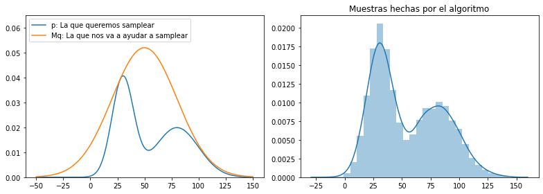

```python
# graficas
info_q = [50,30]
x = np.arange(-50, 151)
M = max(p(x) / q(x)) #Asegura que Mq > p

fig, ax = plt.subplots(1,2, figsize=(11,4))
ax[0].plot(x, p(x), label = 'p: La que queremos samplear')
ax[0].plot(x, M*q(x), label = 'Mq: La que nos va a ayudar a samplear')
ax[0].set_ylim([0,0.065])
ax[0].legend(loc='upper left')


s = rejection_sampling(iter=10000)
sns.distplot(s, ax = ax[1])
plt.title('Muestras hechas por el algoritmo')
plt.tight_layout()
plt.show()
```

Sampleo MCMC con Metropolis Hastings:  
Tomar muestras de p(x) via una distribución más simple q(x) (roja) que se puede mover. Los movimientos son markovianos: solo dependen de la posición actual.

[figure not shown]

Metropolis Hastings puede generar muestras de distribuciones arbitrarias. Acá vemos ejemplos de diferentes propuestas q(x) con diferente movilidad (desviaciones estandar)

[figure not shown]

Fuente: Andrieu, et al, (2003)

Algunas alternativas de algoritmos para samplear:

- PyMC (Python)
- Edward (Python)
- Stan (Python, R, Julia, Stata, Matlab)
- JAGS (Python, R)

# Cognición Bayesiana: Sampleadores

Un sampleador Bayesiano via MCMC puede explicar sesgos clásicos en toma de decisiones

[figure not shown]

Fuente: Sanborn & Chater (2016)

El algoritmo puede no explorar todo el espacio de hipótesis

[figure not shown]

Fuente: Sanborn & Chater (2016)

El algoritmo puede no explorar todo el espacio de hipótesis

[figure not shown]

Fuente: Sanborn & Chater (2016)

Veamos un caso que puede, en principio, explicarse por características del sampleador

Mitad de ustedes cierren los ojos. No los abran hasta que les diga.

La otra mitad hagan la siguiente multiplicación en menos de 3 segundos y escriban el resultado en un papel (NO HABLEN).

$$ 8 \times 7\times 6\times 5\times 4\times 3\times 2\times 1 $$

Abran los ojos.

Los que acaban de abrir los ojos, hagan esta multiplicación, en menos de 3 segundos y escriban el resultado en un papel:

$$ 1 \times 2\times 3\times 4\times 5\times 6\times 7\times 8 $$

La diferencia se da por anchoring effects.

Es importante. Por ejemplo, en economía anchoring effects *''...challenge the central premise of welfare economics that choices reveal true preferences...''* (Ariely, et al, 2003)(pp. 102)

[figure not shown]

¿Cómo explicarlo? Es difícil, pero aca va una hipótesis Bayesiana:

Sampleador sesgado que empieza con el anchor. Solo después de varias iteraciones cae el sesgo.

[figure not shown]

# Conclusiones

¿Por qué cognición bayesiana?

Es un mundo ambiguo/incierto. El cerebro tiene que inferir la probabilidad de diferentes hipótesis

[figure not shown]